# Medicare at 65: Fuzzy RD Estimates

Medicare coverage as the first stage, NHIS 1992–1996

# 1 Setup

Loads the shared RD functions and data (same as the sharp RD files), adds the fuzzy-only variables, and builds the matched IV samples. Checks that duplicate the sharp RD files (age coding, age heaping, covariate balance and response rates in the full outcome samples, employment at 65, outcome placebos at the sharp settings) are not repeated here.

```r
knitr::opts_chunk$set(echo=TRUE,message=FALSE,error=FALSE,
                      fig.width=9,fig.height=5,dpi=160,fig.align='center')
source('rd_functions.R')
root <- find_root()
out <- file.path(root,'output','fuzzy_rd')
dir.create(out,recursive=TRUE,showWarnings=FALSE)
d <- load_rd_data(root)
H <- 5; H_alt <- c(3,4,5,6,7)
outcomes <- c('sawdr','inhosp')
outcome_names <- c(sawdr='Doctor visit in past year',inhosp='Overnight hospital stay in past year')
# Fuzzy-only variables: survey-year dummies (year-composition check), the joint
# doctor + Medicare response indicator, and reconstructed NHIS source-scale
# weights (1993 and 1996 doubled back; sensitivity only, never the main weights).
for(j in 1993:1996) d[[paste0('year',j)]] <- as.numeric(d$year==j)
d$included_primary <- as.numeric(!is.na(d$sawdr) & !is.na(d$mcare))
d$wt_nhis <- d$wt*ifelse(d$year %in% c(1993,1996),2,1)
stopifnot(anyNA(d$sawdr),                     # full CSV keeps missing doctor answers
          all(d$post65==as.integer(d$age4>=65)),
          all(abs(d$age4*4-round(d$age4*4))<1e-8),
          all(rowSums(d[c('wnh','bnh','hispanic','onh')])==1),
          all(d$region %in% 1:4), all(is.na(d$educ) | d$educ %in% 0:20))
# Matched IV samples: the outcome and Medicare must both be observed, so the
# reduced form and first stage use identical respondents.
iv <- list(sawdr=subset(d,!is.na(sawdr) & !is.na(mcare)),
           inhosp=subset(d,!is.na(inhosp) & !is.na(mcare)))
doc_resp <- subset(d,!is.na(sawdr))
# Helpers for this report.
crit <- qnorm(.975)
est_ci <- function(est,se) sprintf('%s [%s, %s]',pct(est),pct(est-crit*se),pct(est+crit*se))
eff_ci <- function(z) sprintf('%s %s',pct(z$estimate),ci(z))
iv_rows <- function(fits,labels) cbind(specification=labels,rd_rows(fits))
show_table <- function(x,caption=NULL)
  cat(knitr::kable(x,caption=caption,align=c('l',rep('r',ncol(x)-1)),row.names=FALSE),sep='\n')
# Fixed-bandwidth robust bias-corrected (RBC) fuzzy RD from rdrobust, used only
# as an inference check. Both bandwidths are fixed; nothing is data-driven.
rd_warnings <- character()
fit_rbc <- function(s,y,h=H,b=H) withCallingHandlers(
  rdrobust::rdrobust(y=s[[y]],x=s$age4,c=65,fuzzy=s$mcare,weights=s$wt/mean(s$wt),
    p=1,q=2,h=h,b=b,covs=model.matrix(~factor(year),s)[,-1,drop=FALSE],
    kernel='triangular',masspoints='adjust',vce='nn'),
  warning=function(w) {rd_warnings <<- c(rd_warnings,conditionMessage(w)); invokeRestart('muffleWarning')})
```

# 2 Samples

Counts the matched IV samples (outcome and Medicare observed) and the hospital sample that also requires a doctor answer. The sharp identification file reports the outcome-only samples.

```r
win <- function(s) subset(s,abs(age4-65)<H)
samples <- list(iv$sawdr,iv$inhosp,subset(iv$inhosp,!is.na(sawdr)))
flow <- data.frame(Sample=c('Doctor IV sample','Hospital IV sample','Hospital IV sample, doctor answer also observed'),
  Requires=c('Doctor-visit and Medicare answers','Hospital-stay and Medicare answers','Hospital, doctor and Medicare answers'),
  `All ages`=fmt_n(sapply(samples,nrow)),
  `Within 5 years of 65`=fmt_n(sapply(samples,function(s) nrow(win(s)))),
  `N left (below 65)`=fmt_n(sapply(samples,function(s) sum(win(s)$age4<65))),
  `N right (65 and above)`=fmt_n(sapply(samples,function(s) sum(win(s)$age4>=65))),check.names=FALSE)
show_table(flow)
```

| Sample | Requires | All ages | Within 5 years of 65 | N left (below 65) | N right (65 and above) |
| --- | --- | --- | --- | --- | --- |
| Doctor IV sample | Doctor-visit and Medicare answers | 65,158 | 32,709 | 16,027 | 16,682 |
| Hospital IV sample | Hospital-stay and Medicare answers | 66,010 | 33,113 | 16,218 | 16,895 |
| Hospital IV sample, doctor answer also observed | Hospital, doctor and Medicare answers | 65,158 | 32,709 | 16,027 | 16,682 |

Missing answers by survey year (all ages), with the input file checksum.

```r
miss <- function(s,label) data.frame(Year=label,N=nrow(s),
  `Doctor missing`=sum(is.na(s$sawdr)),`Doctor missing (%)`=sprintf('%.2f',100*mean(is.na(s$sawdr))),
  `Hospital missing`=sum(is.na(s$inhosp)),`Hospital missing (%)`=sprintf('%.2f',100*mean(is.na(s$inhosp))),
  `Medicare missing`=sum(is.na(s$mcare)),`Medicare missing (%)`=sprintf('%.2f',100*mean(is.na(s$mcare))),check.names=FALSE)
show_table(rbind(do.call(rbind,lapply(split(d,d$year),function(s) miss(s,s$year[1]))),miss(d,'All years')))
```

| Year | N | Doctor missing | Doctor missing (%) | Hospital missing | Hospital missing (%) | Medicare missing | Medicare missing (%) |
| --- | --- | --- | --- | --- | --- | --- | --- |
| 1992 | 19496 | 243 | 1.25 | 0 | 0.00 | 970 | 4.98 |
| 1993 | 9585 | 105 | 1.10 | 0 | 0.00 | 636 | 6.64 |
| 1994 | 18030 | 278 | 1.54 | 0 | 0.00 | 1573 | 8.72 |
| 1995 | 14802 | 298 | 2.01 | 0 | 0.00 | 1183 | 7.99 |
| 1996 | 8838 | 205 | 2.32 | 0 | 0.00 | 379 | 4.29 |
| All years | 70751 | 1129 | 1.60 | 0 | 0.00 | 4741 | 6.70 |

```r
csv_md5 <- unname(tools::md5sum(file.path(root,'data','nhis_clean_full.csv')))
```

Input file `data/nhis_clean_full.csv`, MD5 checksum df83f32a6bdc55bc2e7721b67c56ac2c.

# 3 Main estimates

Estimates the fuzzy RD for both outcomes with `fit_fuzzy()`: local linear, ±5 years, triangular kernel × survey weights, year fixed effects, Medicare as the first stage, HC1 standard errors that account for the covariance between the two jumps. Holm p-values are across the two outcomes.

```r
main <- lapply(setNames(outcomes,outcomes),function(y) fit_fuzzy(iv[[y]],y,h=H,label=paste('Main',y)))
main_table <- iv_rows(main,unname(outcome_names))
main_table$p_holm <- p.adjust(main_table$p_value,'holm')
```

Checks the doctor estimate and its HC1 standard error against the direct just-identified IV (2SLS) formulas.

```r
s <- main$sawdr$data; Q <- model.matrix(main$sawdr$reduced_form$model)
X <- Q; X[,'eligible'] <- s$mcare
B <- solve(crossprod(Q,s$w*X)); b <- drop(B%*%crossprod(Q,s$w*s$sawdr))
e <- s$sawdr-drop(X%*%b)
V <- nrow(Q)/(nrow(Q)-ncol(Q))*B%*%crossprod(Q*(s$w*e))%*%t(B)
stopifnot(abs(b[['eligible']]-main$sawdr$row$estimate)<1e-7,
          abs(sqrt(V['eligible','eligible'])-main$sawdr$row$se)<1e-7)
```

## 3.1 Matched samples and fuzzy RD decomposition

Tables 5.1 and D1 split each fuzzy estimate into its Medicare first stage and outcome reduced form, both estimated on the same respondents.

```r
decomposition <- function(f) c(n_lr(f),fmt_n(f$N),paste(f$cells_left,f$cells_right,sep=' / '),
  est_ci(f$first_stage,f$se_fs),est_ci(f$reduced_form,f$se_rf),eff_ci(f),pct(f$se),
  paste(pv(f$p_value),pv(f$p_holm),sep=' / '),sprintf('%.1f',f$F),paste0(pct(f$below_rate),'%'))
d1 <- data.frame(Quantity=c('N below / at or above 65','Total N','Age cells below / at or above 65',
  'Medicare first stage and 95% CI (pp)','Outcome reduced form and 95% CI (pp)',
  'Fuzzy effect and 95% CI (pp)','HC1 standard error (pp)','Pointwise p / Holm p',
  'First-stage HC1 Wald F','Fitted utilisation just below 65'),
  Doctor=decomposition(main_table[1,]),Hospital=decomposition(main_table[2,]))
show_table(d1,'Tables 5.1 and D1: matched samples and fuzzy RD decomposition')
```

Tables 5.1 and D1: matched samples and fuzzy RD decomposition

| Quantity | Doctor | Hospital |
| --- | --- | --- |
| N below / at or above 65 | 16,027 / 16,682 | 16,218 / 16,895 |
| Total N | 32,709 | 33,113 |
| Age cells below / at or above 65 | 19 / 20 | 19 / 20 |
| Medicare first stage and 95% CI (pp) | 60.35 [58.39, 62.31] | 60.21 [58.25, 62.16] |
| Outcome reduced form and 95% CI (pp) | 1.66 [-0.13, 3.46] | 1.68 [0.09, 3.27] |
| Fuzzy effect and 95% CI (pp) | 2.76 [-0.21, 5.73] | 2.78 [0.15, 5.42] |
| HC1 standard error (pp) | 1.52 | 1.35 |
| Pointwise p / Holm p | 0.0688 / 0.077 | 0.0385 / 0.077 |
| First-stage HC1 Wald F | 3635.6 | 3642.3 |
| Fitted utilisation just below 65 | 83.48% | 11.09% |

## 3.2 First stage and reduced form plots

Figure D1 plots Medicare coverage in the doctor IV sample; the second figure plots each outcome in its own IV sample (the reduced form). Points are weighted quarter-age means; lines are the year-standardised local linear fits. The sharp estimation file plots the outcomes in the full outcome samples instead.

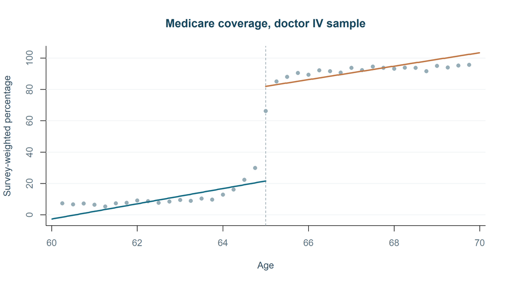

Figure D1: Medicare coverage in the doctor IV sample

```r
plot_rd(iv$sawdr,'mcare',H,main='Medicare coverage, doctor IV sample',fit=main$sawdr$first_stage)
```

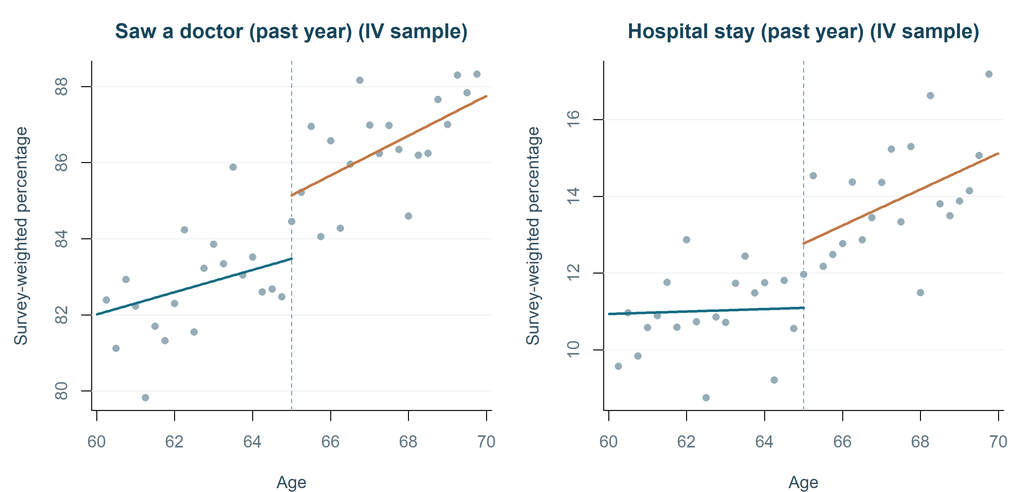

Outcomes in the matched IV samples (the fuzzy RD numerators)

```r
par(mfrow=c(1,2),mar=c(4,4.5,3,1))
for(y in outcomes) plot_rd(iv[[y]],y,H,main=paste(rd_labels[y],'(IV sample)'),fit=main[[y]]$reduced_form)
```

```r
par(mfrow=c(1,1))
```

# 4 Inference sensitivity

Table D6 compares the main HC1 interval with age-cell clustered standard errors (CR1, t with G − 1 degrees of freedom) and rdrobust’s robust bias-corrected interval at fixed h = b = 5. The rdrobust point estimate must equal the main estimate.

```r
rbc <- lapply(setNames(outcomes,outcomes),function(y) fit_rbc(iv[[y]],y))
stopifnot(abs(rbc$sawdr$coef[1,1]-main$sawdr$row$estimate)<1e-6,
          abs(rbc$sawdr$tau_T[1]-main$sawdr$row$first_stage)<1e-6,
          abs(rbc$inhosp$coef[1,1]-main$inhosp$row$estimate)<1e-6)
m <- main$sawdr$row; mh <- main$inhosp$row
tcrit <- qt(.975,m$G-1)
inference <- data.frame(Method=c('Doctor: HC1 IV','Doctor: age-cell CR1, t(G-1)','Doctor: robust bias correction',
                                 'Hospital: HC1 IV','Hospital: robust bias correction'),
  `Centre (pp)`=pct(c(m$estimate,m$estimate,rbc$sawdr$coef[3,1],mh$estimate,rbc$inhosp$coef[3,1])),
  `SE (pp)`=pct(c(m$se,m$cluster_se,rbc$sawdr$se[3,1],mh$se,rbc$inhosp$se[3,1])),
  `95% CI (pp)`=c(ci(m),sprintf('[%s, %s]',pct(m$estimate-tcrit*m$cluster_se),pct(m$estimate+tcrit*m$cluster_se)),
                  sprintf('[%s, %s]',pct(rbc$sawdr$ci[3,1]),pct(rbc$sawdr$ci[3,2])),ci(mh),
                  sprintf('[%s, %s]',pct(rbc$inhosp$ci[3,1]),pct(rbc$inhosp$ci[3,2]))),check.names=FALSE)
show_table(inference,'D6: inference sensitivity')
```

D6: inference sensitivity

| Method | Centre (pp) | SE (pp) | 95% CI (pp) |
| --- | --- | --- | --- |
| Doctor: HC1 IV | 2.76 | 1.52 | [-0.21, 5.73] |
| Doctor: age-cell CR1, t(G-1) | 2.76 | 1.16 | [0.42, 5.10] |
| Doctor: robust bias correction | 4.97 | 2.27 | [0.53, 9.42] |
| Hospital: HC1 IV | 2.78 | 1.35 | [0.15, 5.42] |
| Hospital: robust bias correction | 3.80 | 1.98 | [-0.07, 7.68] |

rdrobust warnings: Mass points detected in the running variable. (mass points are expected with quarter-year ages).

# 5 Identification checks in the IV sample

These checks use the matched IV samples, so they differ from the sharp identification file, which runs balance (eight covariates), response rates and employment in the full outcome samples without requiring Medicare.

## 5.1 Covariate continuity

Table D2A tests eleven covariates in the doctor IV sample (±5 years, year fixed effects), with Holm p-values across the eleven. Education is in years; other jumps are in percentage points.

```r
cov_labels <- c(female='Female',wnh='White non-Hispanic',bnh='Black non-Hispanic',hispanic='Hispanic',
  onh='Other non-Hispanic',educ='Education (years)',lowed_clean='Below high school',
  region_1='Northeast',region_2='Midwest',region_3='South',region_4='West')
jump_table <- function(t,labels) {
  yrs <- t$outcome=='educ'
  data.frame(Variable=unname(labels[t$outcome]),
    Jump=ifelse(yrs,sprintf('%.2f',t$estimate),pct(t$estimate)),
    `95% CI`=ifelse(yrs,sprintf('[%.2f, %.2f]',t$ci_lower,t$ci_upper),ci(t)),
    `Raw p`=pv(t$p_value),`Holm p`=pv(t$p_holm),N=fmt_n(t$N),`N left / right`=n_lr(t),check.names=FALSE)
}
balance <- rd_rows(lapply(names(cov_labels),function(v) fit_rd(iv$sawdr,v,H,label=paste('IV balance',v))))
balance$p_holm <- p.adjust(balance$p_value,'holm')
show_table(jump_table(balance,cov_labels),'D2A: doctor IV covariate balance')
```

D2A: doctor IV covariate balance

| Variable | Jump | 95% CI | Raw p | Holm p | N | N left / right |
| --- | --- | --- | --- | --- | --- | --- |
| Female | -1.37 | [-3.84, 1.10] | 0.276 | 1 | 32,709 | 16,027 / 16,682 |
| White non-Hispanic | 0.35 | [-1.45, 2.16] | 0.702 | 1 | 32,709 | 16,027 / 16,682 |
| Black non-Hispanic | 0.51 | [-0.81, 1.82] | 0.448 | 1 | 32,709 | 16,027 / 16,682 |
| Hispanic | -0.28 | [-1.28, 0.72] | 0.582 | 1 | 32,709 | 16,027 / 16,682 |
| Other non-Hispanic | -0.58 | [-1.53, 0.37] | 0.232 | 1 | 32,709 | 16,027 / 16,682 |
| Education (years) | -0.05 | [-0.21, 0.11] | 0.560 | 1 | 32,490 | 15,922 / 16,568 |
| Below high school | 0.54 | [-1.73, 2.80] | 0.642 | 1 | 32,490 | 15,922 / 16,568 |
| Northeast | 0.24 | [-1.79, 2.28] | 0.814 | 1 | 32,709 | 16,027 / 16,682 |
| Midwest | -1.13 | [-3.23, 0.98] | 0.294 | 1 | 32,709 | 16,027 / 16,682 |
| South | 1.26 | [-1.09, 3.61] | 0.292 | 1 | 32,709 | 16,027 / 16,682 |
| West | -0.38 | [-2.38, 1.62] | 0.711 | 1 | 32,709 | 16,027 / 16,682 |

## 5.2 Survey-year composition

Table D2B tests whether the share interviewed in each year jumps at 65 in the doctor IV sample. Each year share is regressed without year fixed effects, since it cannot be regressed on its own year indicators.

```r
year_labels <- setNames(paste('Interviewed in',1993:1996),paste0('year',1993:1996))
balance_year <- rd_rows(lapply(names(year_labels),function(v)
  fit_rd(iv$sawdr,v,H,year_fe=FALSE,label=paste('Year composition',v))))
balance_year$p_holm <- p.adjust(balance_year$p_value,'holm')
show_table(jump_table(balance_year,year_labels),'D2B: survey-year composition')
```

D2B: survey-year composition

| Variable | Jump | 95% CI | Raw p | Holm p | N | N left / right |
| --- | --- | --- | --- | --- | --- | --- |
| Interviewed in 1993 | -0.20 | [-1.72, 1.33] | 0.8014 | 1.000 | 32,709 | 16,027 / 16,682 |
| Interviewed in 1994 | -0.15 | [-2.24, 1.94] | 0.8881 | 1.000 | 32,709 | 16,027 / 16,682 |
| Interviewed in 1995 | 2.15 | [-0.10, 4.39] | 0.0611 | 0.244 | 32,709 | 16,027 / 16,682 |
| Interviewed in 1996 | -1.17 | [-2.82, 0.47] | 0.1628 | 0.488 | 32,709 | 16,027 / 16,682 |

## 5.3 Joint response and employment

Table D2C tests whether the share with both a doctor answer and a Medicare answer jumps at 65 (all respondents), and whether employment jumps in the doctor IV sample. The sharp identification file tests each answer separately and employment in the full sample.

```r
joint <- fit_rd(d,'included_primary',H,label='Joint doctor and Medicare response')$row
employment_iv <- fit_rd(iv$sawdr,'emp',H,label='Employment, doctor IV sample')$row
d2c <- rbind(joint,employment_iv)
show_table(data.frame(Diagnostic=c('Doctor and Medicare both observed','Employment in doctor IV sample'),
  `Jump (pp)`=pct(d2c$estimate),`95% CI (pp)`=ci(d2c),p=pv(d2c$p_value),N=fmt_n(d2c$N),check.names=FALSE),
  'D2C: response and employment checks')
```

D2C: response and employment checks

| Diagnostic | Jump (pp) | 95% CI (pp) | p | N |
| --- | --- | --- | --- | --- |
| Doctor and Medicare both observed | 0.68 | [-0.69, 2.05] | 0.332 | 35,513 |
| Employment in doctor IV sample | 0.25 | [-1.99, 2.49] | 0.825 | 32,709 |

# 6 Robustness

## 6.1 Bandwidth

Table D3 re-estimates both fuzzy effects with bandwidths of 3 to 7 years.

```r
bw <- lapply(setNames(outcomes,outcomes),function(y) iv_rows(lapply(H_alt,function(h)
  fit_fuzzy(iv[[y]],y,h=h,label=paste('Bandwidth',y,h))),paste0('h = ',H_alt,' years')))
show_table(data.frame(h=H_alt,`Doctor N`=fmt_n(bw$sawdr$N),`Doctor effect and 95% CI (pp)`=eff_ci(bw$sawdr),
  `Hospital N`=fmt_n(bw$inhosp$N),`Hospital effect and 95% CI (pp)`=eff_ci(bw$inhosp),check.names=FALSE),
  'D3: bandwidth sensitivity')
```

D3: bandwidth sensitivity

| h | Doctor N | Doctor effect and 95% CI (pp) | Hospital N | Hospital effect and 95% CI (pp) |
| --- | --- | --- | --- | --- |
| 3 | 19,403 | 4.49 [-0.09, 9.07] | 19,649 | 3.23 [-0.78, 7.25] |
| 4 | 26,030 | 3.43 [-0.13, 7.00] | 26,356 | 3.06 [-0.08, 6.21] |
| 5 | 32,709 | 2.76 [-0.21, 5.73] | 33,113 | 2.78 [0.15, 5.42] |
| 6 | 39,375 | 2.40 [-0.17, 4.98] | 39,865 | 2.35 [0.06, 4.65] |
| 7 | 45,831 | 2.26 [-0.05, 4.56] | 46,409 | 2.15 [0.09, 4.21] |

## 6.2 Doctor specification checks

Table D4 changes one feature of the doctor model at a time (±5 years):

- local quadratic trends;
- demographic controls (female, Black, Hispanic, other non-Hispanic, years of education, region), compared with the same complete-control sample without them;
- kernel weights only (no survey weights);
- a donut dropping the 65.00 cell, or 64.75–65.25 (`donut = .25` and `.5` in `fit_rd()`, which drops cells with |age − 65| < donut);
- no year fixed effects.

The reconstructed-weight and no-1993 rows are shown in Table D5.

```r
controls <- c('female','bnh','hispanic','onh','educ','region_1','region_2','region_3')
control_sample <- iv$sawdr[complete.cases(iv$sawdr[controls]),]
nhis_weights <- function(s) transform(s,wt=wt_nhis)
spec <- list(
  'Main: linear age trends + year FE'=main$sawdr,
  'Quadratic age trends + year FE'=fit_fuzzy(iv$sawdr,'sawdr',h=H,poly=2,label='Spec quadratic'),
  'Control-complete sample: year FE only'=fit_fuzzy(control_sample,'sawdr',h=H,label='Spec control sample'),
  'Same sample: demographics + year FE'=fit_fuzzy(control_sample,'sawdr',h=H,covars=controls,label='Spec controls'),
  'Unweighted + year FE'=fit_fuzzy(iv$sawdr,'sawdr',h=H,weighted=FALSE,label='Spec unweighted'),
  'Exclude age4 = 65; year FE'=fit_fuzzy(iv$sawdr,'sawdr',h=H,donut=.25,label='Spec donut 65.00'),
  'Exclude 64.75–65.25; year FE'=fit_fuzzy(iv$sawdr,'sawdr',h=H,donut=.5,label='Spec donut 64.75-65.25'),
  'No year effects: diagnostic sensitivity'=fit_fuzzy(iv$sawdr,'sawdr',h=H,year_fe=FALSE,label='Spec no year FE'),
  'Reconstructed source-scale weights + year FE'=fit_fuzzy(nhis_weights(iv$sawdr),'sawdr',h=H,label='Spec NHIS weights'),
  'Exclude partial-year 1993 + year FE'=fit_fuzzy(subset(iv$sawdr,year!=1993),'sawdr',h=H,label='Spec no 1993'))
specifications <- iv_rows(spec,names(spec))
s8 <- specifications[1:8,]
show_table(data.frame(Specification=s8$specification,N=fmt_n(s8$N),`First stage (pp)`=pct(s8$first_stage),
  `Effect and 95% CI (pp)`=eff_ci(s8),p=pv(s8$p_value),check.names=FALSE),
  'D4: doctor specification sensitivity')
```

D4: doctor specification sensitivity

| Specification | N | First stage (pp) | Effect and 95% CI (pp) | p |
| --- | --- | --- | --- | --- |
| Main: linear age trends + year FE | 32,709 | 60.35 | 2.76 [-0.21, 5.73] | 0.0688 |
| Quadratic age trends + year FE | 32,709 | 47.30 | 5.59 [-0.08, 11.25] | 0.0532 |
| Control-complete sample: year FE only | 32,490 | 60.53 | 2.64 [-0.34, 5.61] | 0.0824 |
| Same sample: demographics + year FE | 32,490 | 60.42 | 2.71 [-0.26, 5.68] | 0.0742 |
| Unweighted + year FE | 32,709 | 61.21 | 2.92 [0.09, 5.75] | 0.0433 |
| Exclude age4 = 65; year FE | 31,865 | 65.91 | 2.92 [0.07, 5.77] | 0.0446 |
| Exclude 64.75–65.25; year FE | 30,111 | 71.37 | 2.32 [-0.64, 5.28] | 0.1243 |
| No year effects: diagnostic sensitivity | 32,709 | 60.39 | 2.80 [-0.17, 5.77] | 0.0648 |

## 6.3 Survey weights and 1993

Table D5 drops 1993 (a July–December interview year) for both outcomes, and re-estimates both with the reconstructed NHIS source-scale weights (1993 and 1996 doubled back).

```r
alt <- function(y,s,label) fit_fuzzy(s,y,h=H,label=paste(label,y))
weight_sensitivity <- iv_rows(list(main$sawdr,alt('sawdr',nhis_weights(iv$sawdr),'NHIS weights'),
    alt('sawdr',subset(iv$sawdr,year!=1993),'No 1993'),
    main$inhosp,alt('inhosp',nhis_weights(iv$inhosp),'NHIS weights'),
    alt('inhosp',subset(iv$inhosp,year!=1993),'No 1993')),
  c('Doctor: supplied replication weights (main)','Doctor: reconstructed NHIS source-scale sensitivity',
    'Doctor: exclude partial-year 1993','Hospital: supplied replication weights (main)',
    'Hospital: reconstructed NHIS source-scale sensitivity','Hospital: exclude partial-year 1993'))
w <- weight_sensitivity
show_table(data.frame(Sample=c('All years','Reconstructed NHIS weights','1993 excluded'),
  `Doctor N`=fmt_n(w$N[1:3]),`Doctor effect and 95% CI (pp)`=eff_ci(w[1:3,]),
  `Hospital N`=fmt_n(w$N[4:6]),`Hospital effect and 95% CI (pp)`=eff_ci(w[4:6,]),check.names=FALSE),
  'D5: survey weights and excluding 1993')
```

D5: survey weights and excluding 1993

| Sample | Doctor N | Doctor effect and 95% CI (pp) | Hospital N | Hospital effect and 95% CI (pp) |
| --- | --- | --- | --- | --- |
| All years | 32,709 | 2.76 [-0.21, 5.73] | 33,113 | 2.78 [0.15, 5.42] |
| Reconstructed NHIS weights | 32,709 | 2.94 [-0.23, 6.11] | 33,113 | 2.37 [-0.36, 5.10] |
| 1993 excluded | 28,275 | 3.01 [-0.24, 6.26] | 28,642 | 3.46 [0.54, 6.39] |

Checks that dividing every survey weight by five leaves the estimates and HC1 standard errors unchanged when weights are not normalised (doctor model), and shows the weight totals by year.

```r
unnormalised <- function(s,label) fit_fuzzy(s,'sawdr',h=H,normalise=FALSE,label=label)$row
fields <- c('estimate','reduced_form','first_stage','se','se_rf','se_fs')
scale_wt <- unnormalised(iv$sawdr,'Weight-scale audit: wt')
scale_pool <- unnormalised(transform(iv$sawdr,wt=wt/5),'Weight-scale audit: wt/5')
weight_scale_audit <- data.frame(quantity=fields,using_wt=unlist(scale_wt[fields]),
  using_wt_over5=unlist(scale_pool[fields]))
weight_scale_audit$absolute_difference <- abs(weight_scale_audit$using_wt-weight_scale_audit$using_wt_over5)
stopifnot(max(weight_scale_audit$absolute_difference)<1e-9)
show_table(transform(weight_scale_audit,using_wt=sprintf('%.6f',using_wt),
  using_wt_over5=sprintf('%.6f',using_wt_over5),absolute_difference=format(absolute_difference,digits=2)),
  'Weight-scale check: unnormalised weights wt vs wt/5')
```

Weight-scale check: unnormalised weights wt vs wt/5

| quantity | using_wt | using_wt_over5 | absolute_difference |
| --- | --- | --- | --- |
| estimate | 0.027587 | 0.027587 | 1.0e-16 |
| reduced_form | 0.016648 | 0.016648 | 2.2e-16 |
| first_stage | 0.603476 | 0.603476 | 5.8e-15 |
| se | 0.015159 | 0.015159 | 8.3e-16 |
| se_rf | 0.009167 | 0.009167 | 1.7e-16 |
| se_fs | 0.010009 | 0.010009 | 5.5e-16 |

```r
show_table(do.call(rbind,lapply(split(d,d$year),function(s) data.frame(Year=s$year[1],N=fmt_n(nrow(s)),
  `Restore factor`=ifelse(s$year[1] %in% c(1993,1996),2,1),`Sum of supplied wt`=fmt_n(round(sum(s$wt))),
  `Sum of reconstructed NHIS wt`=fmt_n(round(sum(s$wt_nhis))),check.names=FALSE))),'Survey weight totals by year')
```

Survey weight totals by year

| Year | N | Restore factor | Sum of supplied wt | Sum of reconstructed NHIS wt |
| --- | --- | --- | --- | --- |
| 1992 | 19,496 | 1 | 39,025,825 | 39,025,825 |
| 1993 | 9,585 | 2 | 19,600,794 | 39,201,587 |
| 1994 | 18,030 | 1 | 38,425,436 | 38,425,436 |
| 1995 | 14,802 | 1 | 38,400,836 | 38,400,836 |
| 1996 | 8,838 | 2 | 19,238,602 | 38,477,205 |

## 6.4 Sharp and fuzzy sample comparison

Compares each sharp outcome sample (outcome observed) with the IV samples (Medicare also observed), and repeats the hospital IV requiring a doctor answer too. The IV-sample outcome jumps are the fuzzy numerators. The sharp estimation file’s “Medicare observed” row equals the doctor numerator.

```r
hosp_with_doc <- fit_fuzzy(doc_resp,'inhosp',h=H,label='Hospital IV: doctor answer also required')
sharp_row <- function(s,y,label) fit_rd(s,y,H,label=label)$row
recon <- function(analysis,requires,f) {
  fuzzy <- 'first_stage' %in% names(f)
  data.frame(Analysis=analysis,Requires=requires,N_left=f$n_left,N_right=f$n_right,N=f$N,
    Outcome_jump=if(fuzzy) f$reduced_form else f$estimate,
    Medicare_jump=if(fuzzy) f$first_stage else NA_real_,
    IV_ratio=if(fuzzy) f$estimate else NA_real_)
}
sample_comparison <- rbind(
  recon('Sharp doctor: outcome observed','sawdr',sharp_row(d,'sawdr','Comparison: sharp doctor')),
  recon('Fuzzy doctor: Medicare observed','sawdr, mcare',main$sawdr$row),
  recon('Sharp hospital: outcome observed','inhosp',sharp_row(d,'inhosp','Comparison: sharp hospital')),
  recon('Sharp hospital: doctor answer also observed','inhosp, sawdr',
        sharp_row(doc_resp,'inhosp','Comparison: sharp hospital, doctor answer observed')),
  recon('Fuzzy hospital: Medicare observed','inhosp, mcare',main$inhosp$row),
  recon('Fuzzy hospital: doctor answer also observed','inhosp, mcare, sawdr',hosp_with_doc$row))
sc <- sample_comparison
cat(knitr::kable(data.frame(Analysis=sc$Analysis,Requires=sc$Requires,`N left / right`=n_lr(sc),
  `Outcome jump (pp)`=pct(sc$Outcome_jump),`Medicare jump (pp)`=ifelse(is.na(sc$Medicare_jump),'–',pct(sc$Medicare_jump)),
  `Fuzzy effect (pp)`=ifelse(is.na(sc$IV_ratio),'–',pct(sc$IV_ratio)),check.names=FALSE),
  align='llrrrr',row.names=FALSE),sep='\n')
```

| Analysis | Requires | N left / right | Outcome jump (pp) | Medicare jump (pp) | Fuzzy effect (pp) |
| --- | --- | --- | --- | --- | --- |
| Sharp doctor: outcome observed | sawdr | NULL / NULL | 1.31 | – | – |
| Fuzzy doctor: Medicare observed | sawdr, mcare | NULL / NULL | 1.66 | 60.35 | 2.76 |
| Sharp hospital: outcome observed | inhosp | NULL / NULL | 1.60 | – | – |
| Sharp hospital: doctor answer also observed | inhosp, sawdr | NULL / NULL | 1.63 | – | – |
| Fuzzy hospital: Medicare observed | inhosp, mcare | NULL / NULL | 1.68 | 60.21 | 2.78 |
| Fuzzy hospital: doctor answer also observed | inhosp, mcare, sawdr | NULL / NULL | 1.74 | 60.35 | 2.89 |

Employment jump at 65 (±5 years) in all respondents, in respondents with a doctor answer, and in the doctor IV sample.

```r
employment_comparison <- cbind(Sample=c('All respondents','Doctor answer observed','Doctor IV sample'),
  rbind(sharp_row(d,'emp','Comparison: employment, all'),
        sharp_row(doc_resp,'emp','Comparison: employment, doctor answer observed'),employment_iv))
ec <- employment_comparison
show_table(data.frame(Sample=ec$Sample,`N left / right`=n_lr(ec),`Jump (pp)`=pct(ec$estimate),
  `95% CI (pp)`=ci(ec),p=pv(ec$p_value),check.names=FALSE))
```

| Sample | N left / right | Jump (pp) | 95% CI (pp) | p |
| --- | --- | --- | --- | --- |
| All respondents | 17,496 / 18,017 | 0.81 | [-1.34, 2.95] | 0.460 |
| Doctor answer observed | 17,231 / 17,741 | 0.73 | [-1.43, 2.89] | 0.507 |
| Doctor IV sample | 16,027 / 16,682 | 0.25 | [-1.99, 2.49] | 0.825 |

## 6.5 Placebo cutoffs

Table D7 tests outcome jumps (not fuzzy ratios, since there is no first stage) at false cutoffs in the IV samples. Cutoffs at 63 and 64 use only ages below 65; 66 and 67 use only ages above 65. Windows are ±1.5 years, or ±0.99 years at 64 and 66 so they never reach 65. Holm p-values are across the eight tests. The sharp estimation file runs its own placebos with ±2-year windows in the full outcome samples.

```r
placebos <- do.call(rbind,lapply(c(63,64,66,67),function(cut) {
  hp <- min(1.5,abs(cut-65)-.01)
  rd_rows(lapply(outcomes,function(y) {
    s <- if(cut<65) subset(iv[[y]],age4<65) else subset(iv[[y]],age4>65)
    fit_rd(s,y,hp,cut,label=paste('IV-sample placebo',y,cut))
  }))
}))
placebos$p_holm <- p.adjust(placebos$p_value,'holm')
show_table(data.frame(Outcome=ifelse(placebos$outcome=='sawdr','Doctor','Hospital'),
  Cutoff=placebos$cutoff,h=placebos$bandwidth,N=fmt_n(placebos$N),`Jump (pp)`=pct(placebos$estimate),
  `95% CI (pp)`=ci(placebos),p=pv(placebos$p_value),`Holm p`=pv(placebos$p_holm),check.names=FALSE),
  'D7: placebo outcome discontinuities')
```

D7: placebo outcome discontinuities

| Outcome | Cutoff | h | N | Jump (pp) | 95% CI (pp) | p | Holm p |
| --- | --- | --- | --- | --- | --- | --- | --- |
| Doctor | 63 | 1.50 | 9,285 | 1.05 | [-2.59, 4.68] | 0.572 | 1 |
| Hospital | 63 | 1.50 | 9,398 | 1.72 | [-1.22, 4.66] | 0.251 | 1 |
| Doctor | 64 | 0.99 | 5,895 | 0.50 | [-4.21, 5.22] | 0.834 | 1 |
| Hospital | 64 | 0.99 | 5,965 | -0.24 | [-4.21, 3.72] | 0.905 | 1 |
| Doctor | 66 | 0.99 | 5,964 | 2.11 | [-2.46, 6.68] | 0.365 | 1 |
| Hospital | 66 | 0.99 | 6,041 | 1.69 | [-2.60, 5.97] | 0.440 | 1 |
| Doctor | 67 | 1.50 | 9,238 | -1.46 | [-4.60, 1.67] | 0.359 | 1 |
| Hospital | 67 | 1.50 | 9,359 | 1.08 | [-2.18, 4.34] | 0.517 | 1 |

# 7 Subgroups

Estimates the Medicare first stage, doctor reduced form, fuzzy effect and employment jump within each race × education group of the doctor IV sample (±5 years). All four use the same respondents within a group. Groups need observed education; unlike the sharp files, any-coverage need not be observed, so group counts differ slightly from the sharp subgroup tables. Pre-65 uninsured rates use ages 63 to under 65 and are descriptive only.

```r
subgroups <- do.call(rbind,lapply(1:4,function(g) {
  dg <- subset(iv$sawdr,!is.na(group) & group==g)
  f <- fit_fuzzy(dg,'sawdr',h=H,label=paste('Subgroup',g))$row
  e <- fit_rd(dg,'emp',H,label=paste('Subgroup',g,'employment'))$row
  stopifnot(e$N==f$N)
  before <- subset(dg,abs(age4-65)<H & age4>=63 & age4<65)
  data.frame(group=group_labels[[as.character(g)]],
    pre65_any_insurance=wmean(before$covered2,before$wt),pre65_any_N=sum(!is.na(before$covered2)),
    first_stage=f$first_stage,se_fs=f$se_fs,reduced_form=f$reduced_form,se_rf=f$se_rf,
    fuzzy_estimate=f$estimate,fuzzy_se=f$se,fuzzy_lo=f$ci_lower,fuzzy_hi=f$ci_upper,
    employment_jump=e$estimate,employment_lo=e$ci_lower,employment_hi=e$ci_upper,
    N=f$N,N_left=f$n_left,N_right=f$n_right)
}))
show_table(data.frame(Group=subgroups$group,N=fmt_n(subgroups$N),
  `N left / right`=paste(fmt_n(subgroups$N_left),fmt_n(subgroups$N_right),sep=' / '),
  `Uninsured before 65 (%)`=pct(1-subgroups$pre65_any_insurance),
  `Medicare jump (pp)`=pct(subgroups$first_stage),`Doctor jump (pp)`=pct(subgroups$reduced_form),
  `Fuzzy effect and 95% CI (pp)`=sprintf('%s [%s, %s]',pct(subgroups$fuzzy_estimate),
                                         pct(subgroups$fuzzy_lo),pct(subgroups$fuzzy_hi)),
  `Employment jump (pp)`=pct(subgroups$employment_jump),check.names=FALSE),
  'Subgroup jumps in the doctor IV sample')
```

Subgroup jumps in the doctor IV sample

| Group | N | N left / right | Uninsured before 65 (%) | Medicare jump (pp) | Doctor jump (pp) | Fuzzy effect and 95% CI (pp) | Employment jump (pp) |
| --- | --- | --- | --- | --- | --- | --- | --- |
| White non-Hispanic, high education | 18,803 | 9,370 / 9,433 | 6.86 | 64.03 | 0.42 | 0.65 [-2.93, 4.22] | 0.71 |
| White non-Hispanic, low education | 6,528 | 2,871 / 3,657 | 13.60 | 57.90 | 3.71 | 6.41 [-0.78, 13.60] | 1.93 |
| Other race/ethnicity, high education | 3,387 | 1,863 / 1,524 | 14.47 | 58.53 | 1.91 | 3.27 [-6.65, 13.19] | -4.64 |
| Other race/ethnicity, low education | 3,772 | 1,818 / 1,954 | 28.09 | 44.84 | 4.19 | 9.35 [-3.11, 21.80] | 0.18 |

# 8 Sensitivity figure

Figure 5.1 plots the bandwidth estimates for both outcomes (panel A) and the eight doctor specification checks from Table D4 (panel B), with pointwise HC1 95% intervals.

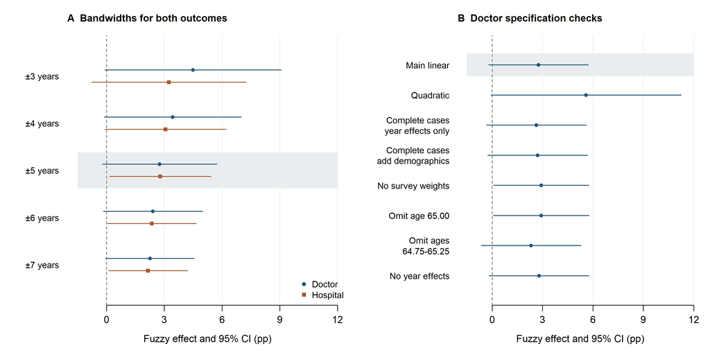

Figure 5.1: fuzzy RD sensitivity with pointwise HC1 intervals

```r
draw_sensitivity <- function() {
  old_par <- par(no.readonly=TRUE); on.exit(par(old_par))
  par(mfrow=c(1,2),mar=c(4.2,5.7,3,.6),mgp=c(2.3,.7,0),family='sans',cex=.88)
  panel <- function(n,labels,title,highlight) {
    plot(NA,xlim=c(-1.5,12),ylim=c(n+.65,.35),xlab='Fuzzy effect and 95% CI (pp)',ylab='',
         yaxt='n',xaxt='n',bty='n')
    rect(-1.5,highlight-.38,12,highlight+.38,col='#E9EDEF',border=NA)
    abline(v=c(3,6,9,12),col='#EEEEEE'); abline(v=0,col='#666666',lty=2)
    axis(1,at=c(0,3,6,9,12)); axis(2,at=seq_len(n),labels=labels,las=1,tick=FALSE,cex.axis=.9)
    title(main=title,adj=0,cex.main=1)
  }
  intervals <- function(z,y,colour,symbol) {
    segments(100*z$ci_lower,y,100*z$ci_upper,y,col=colour,lwd=1.3)
    points(100*z$estimate,y,pch=symbol,col=colour,cex=.85)
  }
  n <- length(H_alt)
  panel(n,paste0('±',H_alt,' years'),'A  Bandwidths for both outcomes',which(H_alt==H))
  intervals(bw$sawdr,seq_len(n)-.13,'#245677',16); intervals(bw$inhosp,seq_len(n)+.13,'#A35B32',15)
  legend('bottomright',legend=c('Doctor','Hospital'),col=c('#245677','#A35B32'),pch=c(16,15),bty='n',cex=.9)
  par(mar=c(4.2,8.7,3,.6))
  panel(8,c('Main linear','Quadratic','Complete cases\nyear effects only','Complete cases\nadd demographics',
            'No survey weights','Omit age 65.00','Omit ages\n64.75-65.25','No year effects'),
        'B  Doctor specification checks',1)
  intervals(s8,1:8,'#245677',16)
}
draw_sensitivity()
```

# 9 Export

Saves three result files: every fuzzy RD estimate (`fuzzy_results.csv`, one row per estimate with a `check` label), every jump diagnostic (`fuzzy_diagnostics.csv`: IV-sample balance, year composition, joint response, employment and placebos), and the subgroup results (`subgroup_results.csv`). Also saves the model sample log (`model_sample_sizes.csv`). All other tables and figures are shown above only.

```r
add <- function(x,check,sample) {x <- cbind(check=check,sample=sample,x)
  if(!'p_holm' %in% names(x)) x$p_holm <- NA_real_; x}
other_h <- H_alt!=H
fuzzy_results <- rbind(
  add(main_table,'main',outcomes),
  add(bw$sawdr[other_h,],'bandwidth','sawdr'),add(bw$inhosp[other_h,],'bandwidth','inhosp'),
  add(specifications[2:8,],'specification','sawdr'),
  add(weight_sensitivity[c(2,3,5,6),],'weights and years',rep(outcomes,each=2)),
  add(iv_rows(list(hosp_with_doc),'Hospital IV: doctor answer also observed'),'hospital sample','inhosp'))
fuzzy_results$relative_to_below <- fuzzy_results$estimate/fuzzy_results$below_rate
write.csv(fuzzy_results,file.path(out,'fuzzy_results.csv'),row.names=FALSE)
fuzzy_diagnostics <- rbind(
  add(balance,'covariate balance','sawdr IV'),
  add(balance_year,'year composition','sawdr IV'),
  add(joint,'joint doctor and Medicare response','all respondents'),
  add(employment_iv,'employment','sawdr IV'),
  add(placebos,'placebo cutoff',paste(placebos$outcome,'IV')))
write.csv(fuzzy_diagnostics,file.path(out,'fuzzy_diagnostics.csv'),row.names=FALSE)
write.csv(subgroups,file.path(out,'subgroup_results.csv'),row.names=FALSE)
export_models(out)
```